# Convergence Test Gibbs Sampling

## How and why do we use Gibbs Sampling

Gibbs sampling is a sampling algorithm designed to draw samples from posterior distributions (however it can be used to draw samples from any distribution like in our case the multivariate normal) when sampling from those distributions are not straight-forward. When we know the conditional distribution of each of the parameters from the target distribution (posterior distribution), and hence it is possible to draw samples from them - we use the Gibbs sampling algorithm (compared to for instance other more general algorithms like Metropolis Hastings).

The algorithm reduces the difficult problem of sampling from a multivariate distribution down to a sequence of simpler univariate problems.Therefore in order to use the Gibbs Sampling algorithm we need to know (and be able to draw samples from) the full conditional distributions for each parameter.

In our case, the target distribution is:

$$\left(\begin{matrix}
\epsilon_{o,g} \\
\epsilon_{o} \\
\epsilon_{p_1} \\
\epsilon_{p_2} \\
\epsilon_s
\end{matrix}\right) \sim MVN_5(A\boldsymbol{\mu}, A\Sigma A^T)$$

Where

$$\Sigma = \left(\begin{matrix}
1-h^2 & 0 & 0 & 0 & 0 \\
0 & h^2 & \frac{h^2}{2} & \frac{h^2}{2} & \frac{h^2}{2} \\
0 & \frac{h^2}{2} & 1 & 0 & \frac{h^2}{2} \\
0 & \frac{h^2}{2} & 0 & 1 & \frac{h^2}{2} \\
0 & \frac{h^2}{2} & \frac{h^2}{2} & \frac{h^2}{2} & 1 \\
\end{matrix}\right) \quad \wedge \quad \boldsymbol{\mu} = \left(\begin{matrix}
0 \\
0 \\
0 \\
0 \\
0
\end{matrix}\right)$$

and $A$ is the solution to:

$$A\left(\begin{matrix}
\epsilon_{o,e} \\
\epsilon_{o,g} \\
\epsilon_{p_1} \\
\epsilon_{p_2} \\
\epsilon_s
\end{matrix}\right) = \left(\begin{matrix}
\epsilon_{o,g} \\
\epsilon_{o} \\
\epsilon_{p_1} \\
\epsilon_{p_2} \\
\epsilon_s
\end{matrix}\right)$$
where $\epsilon_o = \epsilon_{o,e}+\epsilon_{o,g}$ and $\epsilon$ defines liabilities.

In this case we know the univariate distribution of the full conditional distribution for each parameter, which will be normal distributions and can be calculated using:

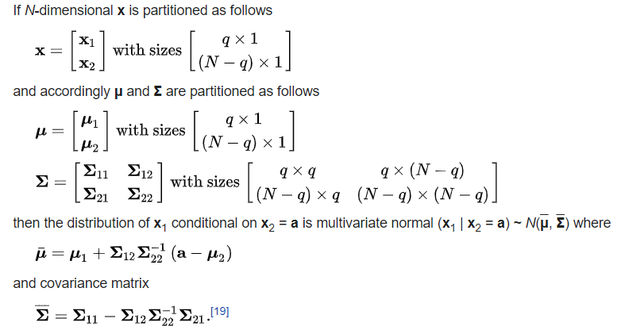

Source: Wikipedia

Once we are able to draw samples from the conditional distributions, the general Gibbs Sampling algorithm is:

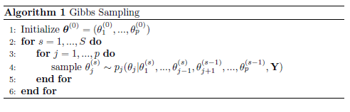

Source: Bayesian Statistical Methods, Reich and Ghosh

Here is our implementation of the Gibbs Sampling algorithm. In the below code, we do not specify any specific upper and lower bound, which is used to draw samples from the truncated version of the multivariate normal. In the subsequent sections we will explore different configurations resulting in different truncated multivariate normal distributions.

```r
set.seed(18)

h2 <- 0.5
nr_sib <- 1
valT <- 0.05 #prevalence (used to define bounds/case - threshold)

CovMatrix <- GWAS::LinearTransformation(GWAS::CovarianceMatrix(h2,nr_sib))
#Below is where we change the bounds depeding on the configuration
LowerBound <- rep(-Inf,nrow(CovMatrix)-1)
UpperBound <- rep(Inf,nrow(CovMatrix)-1)

CondInfo <- GWAS::ConditionalDistribution(CovMatrix)
sigma <- CondInfo$sigma
mu <- CondInfo$mu
# Total number of samples
S <- 6000
my_sample <- matrix(ncol = (length(LowerBound)+1), nrow = S)
#Below is the initial values
vals <- rep(10,(length(LowerBound)+1))
#Running the gibbs-sampling
for (i in 1:S){
  #Child gen
  vals[1] <- rnorm(1,mu[1,] %*% vals[2:length(vals)], sqrt(sigma[1]))
  #REST
  for (p in 2:(length(LowerBound)+1)){
    mu_prod <- mu[p,] %*% vals[-p]
    l1 <- pnorm(LowerBound[p-1], mu_prod, sqrt(sigma[p]))
    u1 <- pnorm(UpperBound[p-1], mu_prod, sqrt(sigma[p]))
    g1 <- runif(1,l1,u1)
    vals[p] <- qnorm(g1,mu_prod, sqrt(sigma[p]))
  }
  my_sample[i,] <- vals
}
```

We will now look at different configurations as well as different initial values and explore the behaviour/convergence of our samples.

### All family-members is a case with start values at $10$

[output not shown]

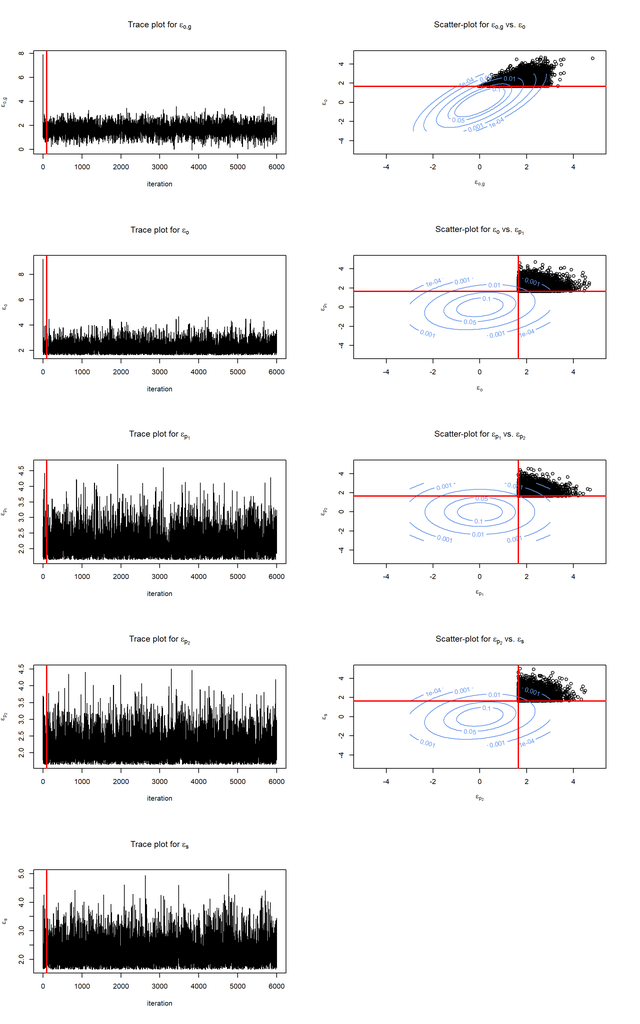

### No family-members is a case with start values at $10$

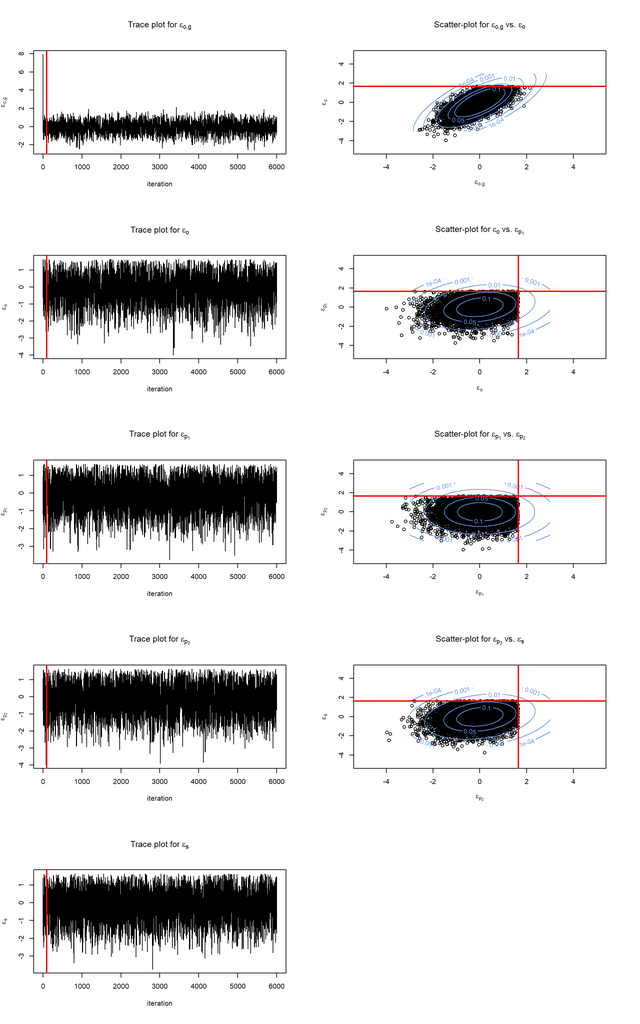